```python
import pandas as pd
import seaborn as sns
import scipy.stats as stats
import numpy as np
import matplotlib.pyplot as plt
import statsmodels.api as sm
```

```python
%cd C:\Users\jtsto\OneDrive\Documents\02 BU FALL 2024\AD 654/week 11/assignment 5
```

```
C:\Users\jtsto\OneDrive\Documents\02 BU FALL 2024\AD 654\week 11\assignment 5
```

# 1

A *The Boeing Coompany*

Aa *The Boeing Company (BA). With everything that has been going on in the news lately with Boeing I thought it would be an interesting company to look at in more detail. Once the pinnacle of American innovation, now is a troubled company that looks to have some serious obstacles to overcome.*

```python
#B,C
BA = pd.read_csv("HistoricalData_BA.csv", index_col="Date", parse_dates=True)
```

```python
#Ca
BA.head()
```

| Date | Close/Last | Volume | Open | High | Low |
| --- | --- | --- | --- | --- | --- |
| 2024-11-15 | $140.19 | 12120100 | $138.14 | $140.3247 | $137.03 |
| 2024-11-14 | $138.14 | 15646710 | $140.80 | $141.55 | $137.22 |
| 2024-11-13 | $139.97 | 21249600 | $145.58 | $145.58 | $139.10 |
| 2024-11-12 | $145.17 | 16746650 | $148.40 | $148.50 | $143.85 |
| 2024-11-11 | $148.96 | 12799080 | $152.00 | $152.50 | $148.07 |

```python
BA.shape
```

```
(252, 5)
```

```python
#Cb
BA.rename(columns={'Close/Last': 'Close'}, inplace=True)

BA.head()
```

| Date | Close | Volume | Open | High | Low |
| --- | --- | --- | --- | --- | --- |
| 2024-11-15 | $140.19 | 12120100 | $138.14 | $140.3247 | $137.03 |
| 2024-11-14 | $138.14 | 15646710 | $140.80 | $141.55 | $137.22 |
| 2024-11-13 | $139.97 | 21249600 | $145.58 | $145.58 | $139.10 |
| 2024-11-12 | $145.17 | 16746650 | $148.40 | $148.50 | $143.85 |
| 2024-11-11 | $148.96 | 12799080 | $152.00 | $152.50 | $148.07 |

```python
#Cc
BA.info()
```

```
<class 'pandas.core.frame.DataFrame'>
DatetimeIndex: 252 entries, 2024-11-15 to 2023-11-16
Data columns (total 5 columns):
 #   Column  Non-Null Count  Dtype
---  ------  --------------  -----
 0   Close   252 non-null    object
 1   Volume  252 non-null    int64
 2   Open    252 non-null    object
 3   High    252 non-null    object
 4   Low     252 non-null    object
dtypes: int64(1), object(4)
memory usage: 11.8+ KB
```

```python
#D
type(BA.index)
```

```
pandas.core.indexes.datetimes.DatetimeIndex
```

```python
BA.index[:10]
```

```
DatetimeIndex(['2024-11-15', '2024-11-14', '2024-11-13', '2024-11-12',
               '2024-11-11', '2024-11-08', '2024-11-07', '2024-11-06',
               '2024-11-05', '2024-11-04'],
              dtype='datetime64[ns]', name='Date', freq=None)
```

D *Yep, it’s successfully indexed by the time values. After checking the index attribute (+ also looking at the 10 first entries) I can confirm it indexed as needed, by date and time (DatetimeIndex).*

E *DatetimeIndex is the index attribute (as above)*

```python
#Ea
max_date = BA.index.max()
min_date = BA.index.min()

print("Max date:", max_date)
print("Min date:", min_date)
```

```
Max date: 2024-11-15 00:00:00
Min date: 2023-11-16 00:00:00
```

```python
#Eb
argmax = BA.index.get_loc(BA.index.max())
argmin = BA.index.get_loc(BA.index.min())

print("Max position:", argmax)
print("Min position:", argmin)
```

```
Max position: 0
Min position: 251
```

Ec *Max/Min are the dates (how it's indexed), maximum value (most recent) and minimum value (least recent). Argmax/Argmin are their positions in the database. In this case they are two different columns that would be the same rows (or entry), it is organized in descending order.*

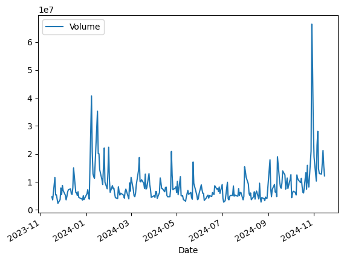

```python
#Fa
BA.plot()
```

Fa.i *Running the plot() here without calling any specific variables looks to output the volume variable on the y-axis. This plot simply just shows us the times of high activity on the ‘trading floor’, typically during periods of big price movement/sector changes/good or bad news/public opinion fluctuations/etc.. In this case I’m pretty sure both times are downward moving as in the beginning of the year there was the door blowout on Alaska airlines and this recent one (volume spike) during the union strike and all other stuff that they’ve had going on. So is an indication of a lot of volatility, the plot shows us nothing about the actual stock price. It would, of course, be helpful to see the actual price of the stock as that is most certainly something we are interested in.*

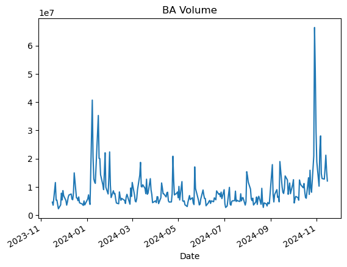

```python
#just making sure... otherwise my comment (above) wouldn't make sense, looks like I'm good
BA['Volume'].plot(title="BA Volume")
```

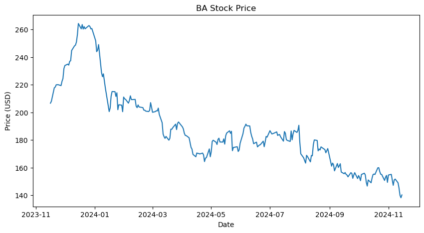

```python
#Fb
BA['Close'] = BA['Close'].replace(r'[\$,]', '', regex=True).astype(float)

plt.figure(figsize=(10, 5))
plt.plot(BA.index, BA['Close'])
plt.xlabel("Date")
plt.ylabel("Price (USD)")
plt.title("BA Stock Price")
plt.show()
```

Fb.i *This one is much more informative, absolutely, when it comes to understanding the price of the stock. The plot shows the price movement (‘Close’) vs. just the volume over the 1-year period. The price definitely dropped substantially immediately after the door blowout this past January and has continued to do so. This last huge spike in volume (previous plot), I’m guessing, may have had something to do with Boeing reportedly selling a bunch of stock to raise capital to help navigate the rocky road ahead - they can thank a few of their previous CEO’s for that (…It’s easy to be a critique on the sidelines, but seriously, it seems like these guys get paid millions upon millions to screw things up).*

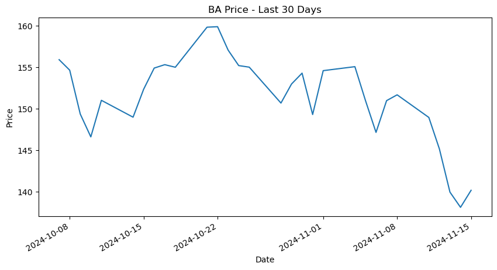

```python
#Fc.i
last_30_days = BA['Close'].iloc[:30]

last_30_days.plot(title="BA Price - Last 30 Days", figsize=(10, 5))
plt.xlabel("Date")
plt.ylabel("Price")
plt.show()
```

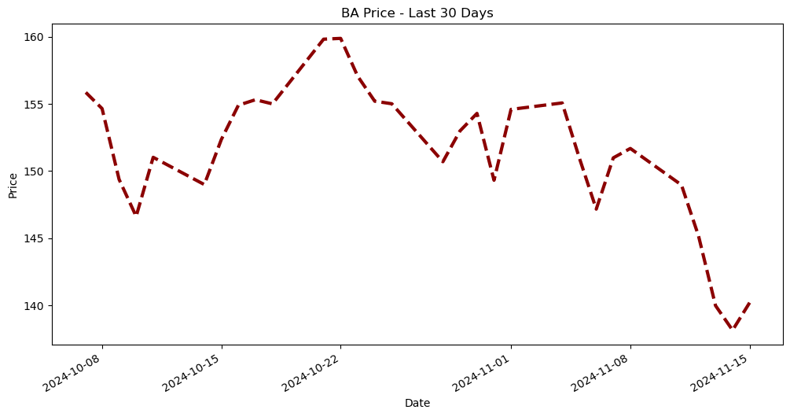

```python
#Fc.ii
last_30_days.plot(
    title="BA Price - Last 30 Days",
    figsize=(12, 6),
    color="darkred",
    linestyle="--",
    linewidth = 3 )

plt.xlabel("Date")
plt.ylabel("Price")
plt.show()
```

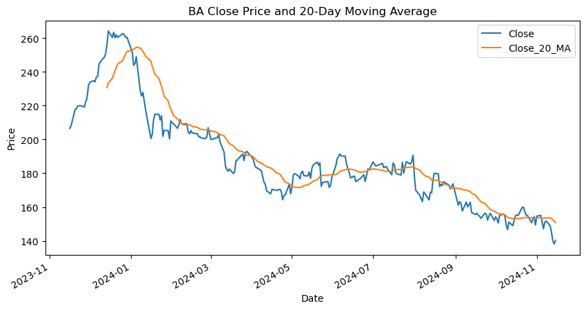

```python
#Ga
BA['Close_20_MA'] = BA['Close'].rolling(window=20).mean()

BA['Close_20_MA'] = BA['Close_20_MA'].shift(-19)

BA[['Close', 'Close_20_MA']].plot(title="BA Close Price and 20-Day Moving Average", figsize=(10, 5))
plt.xlabel("Date")
plt.ylabel("Price")
plt.show()
```

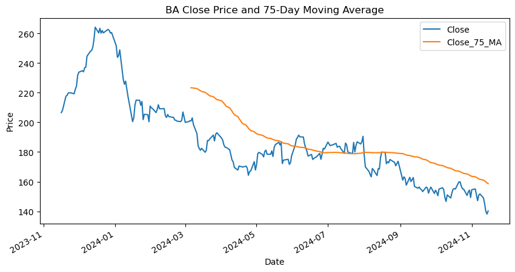

```python
#Gb
BA['Close_75_MA'] = BA['Close'].rolling(window=75).mean()

BA['Close_75_MA'] = BA['Close_75_MA'].shift(-74)

BA[['Close', 'Close_75_MA']].plot(title="BA Close Price and 75-Day Moving Average", figsize=(10, 5))
plt.xlabel("Date")
plt.ylabel("Price")
plt.show()
```

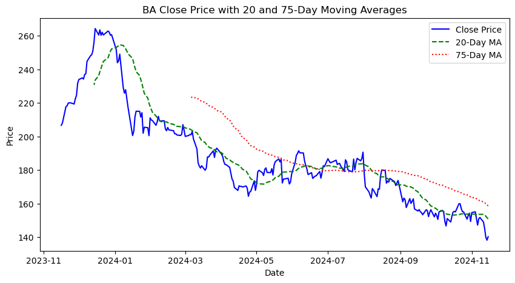

```python
# here's all three
BA['Close_20_MA'] = BA['Close'].rolling(window=20).mean().shift(-19)
BA['Close_75_MA'] = BA['Close'].rolling(window=75).mean().shift(-74)

plt.figure(figsize=(10, 5))

plt.plot(BA.index, BA['Close'], label='Close Price', color='blue', linestyle='-')
plt.plot(BA.index, BA['Close_20_MA'], label='20-Day MA', color='green', linestyle='--')
plt.plot(BA.index, BA['Close_75_MA'], label='75-Day MA', color='red', linestyle=':')

plt.xlabel("Date")
plt.ylabel("Price")
plt.title("BA Close Price with 20 and 75-Day Moving Averages")
plt.legend()
plt.show()
```

Gc *The 20-peroid (day) moving average is, of course, much closer to the actual daily closing price – by design. They both have their pros and cons. Some pros of the 75-peroid (day) are that it ‘smooths’ out the more dramatic variations and makes it easier to spot the overall trend. As a con it misses the precise mark during the best and worst times for the stock during the period it represents. The pros of the 20-peroid (day) moving average, as mentioned initially, is that it follows the actual data more closely. A con would be (well... sort of) that it doesn’t ‘smooth’ things out as nicely so it may be more difficult to visually establish a long-term trend in some cases. The longer periods are likely more useful for the investor who thinks in longer term cycles; the shorter periods perhaps more useful for those who prefer to make quick trades (i.e. shorter holding periods) and/or prefer options contracts with closer expiration dates.*

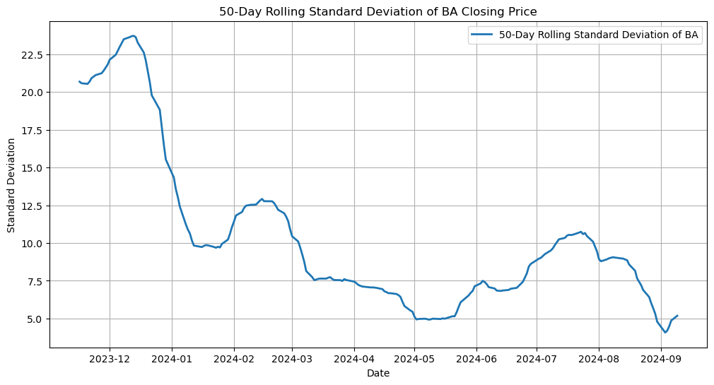

```python
#H
rolling_std = BA['Close'].rolling(window=50).std()

plt.figure(figsize=(12, 6))
plt.plot(rolling_std, label='50-Day Rolling Standard Deviation of BA', linewidth=2)
plt.title('50-Day Rolling Standard Deviation of BA Closing Price')
plt.xlabel('Date')
plt.ylabel('Standard Deviation')
plt.legend()
plt.grid(True)
plt.show()
```

```python
#Ia
BA_quarterly = BA['Close'].resample('QE').mean()

BA_quarterly
```

```
Date
2023-12-31    241.024667
2024-03-31    205.484262
2024-06-30    178.243968
2024-09-30    171.470313
2024-12-31    151.585294
Freq: QE-DEC, Name: Close, dtype: float64
```

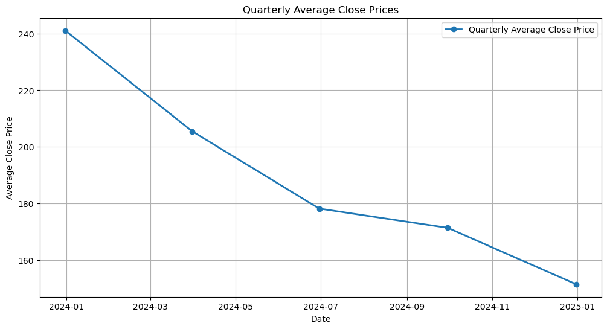

```python
#Ia.i
plt.figure(figsize=(12, 6))
plt.plot(BA_quarterly, label='Quarterly Average Close Price', marker='o', linewidth=2)
plt.title('Quarterly Average Close Prices')
plt.xlabel('Date')
plt.ylabel('Average Close Price')
plt.legend()
plt.grid(True)
plt.show()
```

Ia.ii *First, as we can see from the plot, the resampling most certainly ‘smooths’ things out. Changing the time series here to quarterly vs. daily can help us get a better sense of the overall movement of the BA stock, in this case the price is consistently on a downward trend, its fairly ‘loud-and-clear’ when viewed in this format. Another area where I can imagine resampling being helpful is when the dataset is incredibly large, resampling to make it more manageable would certainly make sense. For example, what if we were looking at the data from 100 years’ worth of a stock’s price (i.e. Proctor & Gamble), we may want to resample to yearly to make it more interpretable to see the big picture.*

# 2

```python
#I
Cscwb = pd.read_csv("schwab_ads.csv")
```

```python
Cscwb.head()
```

|  | Web | Bus_Stop | Newspaper | Sales |
| --- | --- | --- | --- | --- |
| 0 | 230.1 | 37.8 | 69.2 | 22.1 |
| 1 | 44.5 | 39.3 | 45.1 | 10.4 |
| 2 | 17.2 | 45.9 | 69.3 | 12.0 |
| 3 | 151.5 | 41.3 | 58.5 | 16.5 |
| 4 | 180.8 | 10.8 | 58.4 | 17.9 |

```python
Cscwb.shape
```

```
(200, 4)
```

```python
#Ia
Cscwb['Total_Spending'] = Cscwb['Web'] + Cscwb['Bus_Stop'] + Cscwb['Newspaper']
Cscwb.head()
```

|  | Web | Bus_Stop | Newspaper | Sales | Total_Spending |
| --- | --- | --- | --- | --- | --- |
| 0 | 230.1 | 37.8 | 69.2 | 22.1 | 337.1 |
| 1 | 44.5 | 39.3 | 45.1 | 10.4 | 128.9 |
| 2 | 17.2 | 45.9 | 69.3 | 12.0 | 132.4 |
| 3 | 151.5 | 41.3 | 58.5 | 16.5 | 251.3 |
| 4 | 180.8 | 10.8 | 58.4 | 17.9 | 250.0 |

```python
#Ib.i
correlation_TS = Cscwb['Total_Spending'].corr(Cscwb['Sales'])
print("Correlation between Total Spending and Sales:", correlation_TS)
```

```
Correlation between Total Spending and Sales: 0.924917006249931
```

Ib.ii *The correlation here of 0.925 shows there is a strong and positive relationship between Total Spending and Sales. Presumably, the more adds ‘we’ buy, the more ‘we’ sell…*

Ib.iii *One reason to not conclude this right away is we’re not accounting for the possibility that there could have been sales that had nothing to do with the advertisements, these people were going to buy either way, exposure to the add did not change their behavior. Although, with this strong a correlation (0.925) it is certainly looking like the adds are quite effective.*

```python
#Ic
correlation_web_bus_stop = Cscwb['Web'].corr(Cscwb['Bus_Stop'])
correlation_web_newspaper = Cscwb['Web'].corr(Cscwb['Newspaper'])
correlation_bus_stop_newspaper = Cscwb['Bus_Stop'].corr(Cscwb['Newspaper'])

print("Correlation between Web and Bus Stop:", correlation_web_bus_stop)
print("Correlation between Web and Newspaper:", correlation_web_newspaper)
print("Correlation between Bus Stop and Newspaper:", correlation_bus_stop_newspaper)
```

```
Correlation between Web and Bus Stop: 0.054808664465830034
Correlation between Web and Newspaper: 0.056647874965056945
Correlation between Bus Stop and Newspaper: 0.3541037507611754
```

Ic.i *Nothing too high here… The correlations between Web and Bus Stop and Web and Newspaper are showing to be very weak here, they basically have no relationship at all. The correlation between Bus Stop and Newspaper is higher and can go onto the moderate category, which makes sense (Bus Stops and Newspapers tend to gravitate towards each other/are a good combo – think about the ‘old-school’ newspaper dispensers that one may see near bus and train stations in some cities).*

```python
#Id
X = Cscwb[['Web', 'Bus_Stop', 'Newspaper']]
X = sm.add_constant(X)

y = Cscwb['Sales']

model_1 = sm.OLS(y, X)
results_1 = model_1.fit()

print(results_1.summary())
```

```
                            OLS Regression Results
==============================================================================
Dep. Variable:                  Sales   R-squared:                       0.903
Model:                            OLS   Adj. R-squared:                  0.901
Method:                 Least Squares   F-statistic:                     605.4
Date:                Sun, 06 Apr 2025   Prob (F-statistic):           8.13e-99
Time:                        10:30:00   Log-Likelihood:                -383.34
No. Observations:                 200   AIC:                             774.7
Df Residuals:                     196   BIC:                             787.9
Df Model:                           3
Covariance Type:            nonrobust
==============================================================================
                 coef    std err          t      P>|t|      [0.025      0.975]
------------------------------------------------------------------------------
const          4.6251      0.308     15.041      0.000       4.019       5.232
Web            0.0544      0.001     39.592      0.000       0.052       0.057
Bus_Stop       0.1070      0.008     12.604      0.000       0.090       0.124
Newspaper      0.0003      0.006      0.058      0.954      -0.011       0.012
==============================================================================
Omnibus:                       16.081   Durbin-Watson:                   2.251
Prob(Omnibus):                  0.000   Jarque-Bera (JB):               27.655
Skew:                          -0.431   Prob(JB):                     9.88e-07
Kurtosis:                       4.605   Cond. No.                         454.
==============================================================================

Notes:
[1] Standard Errors assume that the covariance matrix of the errors is correctly specified.
```

Id.i *The F-statistic of the model as listed is quite high, 605.4. The probability of the F-statistic quite low, 8.13e-99. Which is ‘next-level’ low, meaning that the model is most certainly quite significant! This is saying to us that the advertisements have a very strong relationship with sales and are statistically significant.*

Id.ii *The p-value for Web are very low (showing as 0.000), particularly when considering the confidence intervals and also the t-statistic, indicating this is the most influential in the group. Bus Stop ads also seem to be very effective and have a very low p-value (showing as 0.000), the t-statistic lower (than Web) but is still certainly showing to be significant in its relationship with sales. Newspaper ads, on the other hand, have a very high p-value (showing as 0.954) and low t-statistic indicating they have nearly no effect on sales at all.*

```python
#Ie
Cscwb['Web_Bus_Stop'] = Cscwb['Web'] * Cscwb['Bus_Stop']

X = Cscwb[['Web', 'Bus_Stop', 'Web_Bus_Stop']]
X = sm.add_constant(X)

y = Cscwb['Sales']

model_2 = sm.OLS(y, X)
results_2 = model_2.fit()

print(results_2.summary())
```

```
                            OLS Regression Results
==============================================================================
Dep. Variable:                  Sales   R-squared:                       0.914
Model:                            OLS   Adj. R-squared:                  0.913
Method:                 Least Squares   F-statistic:                     694.7
Date:                Sun, 06 Apr 2025   Prob (F-statistic):          3.90e-104
Time:                        10:30:00   Log-Likelihood:                -370.83
No. Observations:                 200   AIC:                             749.7
Df Residuals:                     196   BIC:                             762.9
Df Model:                           3
Covariance Type:            nonrobust
================================================================================
                   coef    std err          t      P>|t|      [0.025      0.975]
--------------------------------------------------------------------------------
const            6.1926      0.410     15.101      0.000       5.384       7.001
Web              0.0436      0.002     17.512      0.000       0.039       0.048
Bus_Stop         0.0423      0.015      2.869      0.005       0.013       0.071
Web_Bus_Stop     0.0004   8.67e-05      5.110      0.000       0.000       0.001
==============================================================================
Omnibus:                        8.006   Durbin-Watson:                   2.295
Prob(Omnibus):                  0.018   Jarque-Bera (JB):               10.847
Skew:                          -0.258   Prob(JB):                      0.00441
Kurtosis:                       4.017   Cond. No.                     1.80e+04
==============================================================================

Notes:
[1] Standard Errors assume that the covariance matrix of the errors is correctly specified.
[2] The condition number is large, 1.8e+04. This might indicate that there are
strong multicollinearity or other numerical problems.
```

Ie.i *All the p-vales here a very low (0.000, 0.005, 0.000) which tells us that all of the variables, including the interaction between Web and Bus Stop are significant in predicting sales.*

```python
#Ie.ii
X = Cscwb[['Web', 'Bus_Stop']]
X = sm.add_constant(X)

y = Cscwb['Sales']

model_3 = sm.OLS(y, X)
results_3 = model_3.fit()

print(results_3.summary())
```

```
                            OLS Regression Results
==============================================================================
Dep. Variable:                  Sales   R-squared:                       0.903
Model:                            OLS   Adj. R-squared:                  0.902
Method:                 Least Squares   F-statistic:                     912.7
Date:                Sun, 06 Apr 2025   Prob (F-statistic):          2.39e-100
Time:                        10:30:00   Log-Likelihood:                -383.34
No. Observations:                 200   AIC:                             772.7
Df Residuals:                     197   BIC:                             782.6
Df Model:                           2
Covariance Type:            nonrobust
==============================================================================
                 coef    std err          t      P>|t|      [0.025      0.975]
------------------------------------------------------------------------------
const          4.6309      0.290     15.952      0.000       4.058       5.203
Web            0.0544      0.001     39.726      0.000       0.052       0.057
Bus_Stop       0.1072      0.008     13.522      0.000       0.092       0.123
==============================================================================
Omnibus:                       16.227   Durbin-Watson:                   2.252
Prob(Omnibus):                  0.000   Jarque-Bera (JB):               27.973
Skew:                          -0.434   Prob(JB):                     8.43e-07
Kurtosis:                       4.613   Cond. No.                         425.
==============================================================================

Notes:
[1] Standard Errors assume that the covariance matrix of the errors is correctly specified.
```

Ie.ii *The r-squared values are very close here (0.903 vs. 0.914). The one that uses the interaction is just a touch higher meaning its slightly better at predicting sales (by about 1%) than that last model without it (a slightly better fit).*

```python
#Ie.iii
Cscwb['Web_Bus_Stop'] = Cscwb['Web'] * Cscwb['Bus_Stop']

X = sm.add_constant(Cscwb[['Web', 'Bus_Stop', 'Web_Bus_Stop']])
y = Cscwb['Sales']

model_4 = sm.OLS(y, X).fit()

new_data = pd.DataFrame({
    'const': [1],
    'Web': [130],
    'Bus_Stop': [21],
    'Web_Bus_Stop': [130 * 21]
})

predicted_sales = round(model_4.predict(new_data).iloc[0], 2)
print("Predicted Sales:", predicted_sales)
```

```
Predicted Sales: 13.96
```

Ie.iv *What the created interaction variable (Web_Bus_Stop) is showing us is how the combined effect of the two advertisements (Web and Bus Stop) can affect overall sales. For example, perhaps someone comes across a web advertisement while reading the daily news/etc. (social media or otherwise) during his or her morning coffee routine at home, only to again see the same advertisement (same brand/company/etc.) later in the day at the bus stop or similar. This second ‘look’ here really reinforces the message and may help to plant the idea into this potential buyers/subscribers/etc. mind to further pursue the product. They both work together quite well, both in the model and in my reflection of the combination effect of the two out there in the applicable world.*